# Cruise_project

Milena Atanasova, Annamaria Culpo

December 2022

This project has been elaborated for the course of “Laboratory of customers and business analytics” at the University of Trento, a.y. 2022 – 2023. A cruise company (e.g. Costa) would like to add a new cruise line proposal for the summer season of 2023. It is considering making a customer survey and conducting a traditional conjoint analysis of potential service profiles

# Importing and exploring the dataset

First, we import the data about the Cruise survey for conjoint analysis. It is in long format.

```r
library(lme4)
library(lattice)
cruise <- read.csv("Cruise_data.csv", sep=";")
str(cruise)
```

```
## 'data.frame':    6000 obs. of  8 variables:
##  $ resp.id    : int  1 1 1 1 1 1 1 1 1 1 ...
##  $ rating     : int  8 5 10 1 5 4 6 10 5 4 ...
##  $ Brand      : chr  "MSC" "MSC" "Costa" "MSC" ...
##  $ Destination: chr  "Greece" "Greece" "Spain" "Egypt" ...
##  $ Price      : int  1200 700 1200 700 300 1200 700 1200 1200 1200 ...
##  $ Duration   : int  14 7 14 14 21 7 21 14 21 7 ...
##  $ Amenities  : chr  "Spa" "Spa" "Spa" "Sport" ...
##  $ age        : chr  "old" "old" "old" "old" ...
```

Let’s understand how many respondents there are.

```r
table(cruise$resp.id)
```

```
##
##   1   2   3   4   5   6   7   8   9  10  11  12  13  14  15  16  17  18  19  20
##  20  20  20  20  20  20  20  20  20  20  20  20  20  20  20  20  20  20  20  20
##  21  22  23  24  25  26  27  28  29  30  31  32  33  34  35  36  37  38  39  40
##  20  20  20  20  20  20  20  20  20  20  20  20  20  20  20  20  20  20  20  20
##  41  42  43  44  45  46  47  48  49  50  51  52  53  54  55  56  57  58  59  60
##  20  20  20  20  20  20  20  20  20  20  20  20  20  20  20  20  20  20  20  20
##  61  62  63  64  65  66  67  68  69  70  71  72  73  74  75  76  77  78  79  80
##  20  20  20  20  20  20  20  20  20  20  20  20  20  20  20  20  20  20  20  20
##  81  82  83  84  85  86  87  88  89  90  91  92  93  94  95  96  97  98  99 100
##  20  20  20  20  20  20  20  20  20  20  20  20  20  20  20  20  20  20  20  20
## 101 102 103 104 105 106 107 108 109 110 111 112 113 114 115 116 117 118 119 120
##  20  20  20  20  20  20  20  20  20  20  20  20  20  20  20  20  20  20  20  20
## 121 122 123 124 125 126 127 128 129 130 131 132 133 134 135 136 137 138 139 140
##  20  20  20  20  20  20  20  20  20  20  20  20  20  20  20  20  20  20  20  20
```

[output cut: 16 more lines]

```r
unique(table(cruise$resp.id))
```

```
## [1] 20
```

There are 300 respondents, each one rating 20 product profiles. Now we check if the attributes are balanced among all the product profiles.

```r
sapply(cruise[,3:8], table)
```

```
## $Brand
##
##          Costa            MSC RoyalCaribbean
##           1800           3000           1200
##
## $Destination
##
##  Egypt Greece Sicily  Spain
##    600   2100   1200   2100
##
## $Price
##
##  300  700 1200
## 1800 1800 2400
##
## $Duration
##
##    7   14   21
## 1500 2700 1800
##
## $Amenities
##
## Animation       Spa     Sport
##       600      2700      2700
##
## $age
##
## adult   old young
##  3040  1720  1240
```

The level “Animation” of the Amenities attribute is a bit underrepresented with respect to the other levels, as is for “Egypt” in the attribute Destination. One possible explanation for the latter could be that Egypt is a new exotic destination still under exploration. From the output we can also see that “adult” is the age category that is more present than the old and young individuals. This could be explained by the fact that it is the kind of customer that usually goes on a cruise.

```r
prop.table(table(cruise$Brand))
```

```
##
##          Costa            MSC RoyalCaribbean
##            0.3            0.5            0.2
```

```r
prop.table(table(cruise$Destination))
```

```
##
##  Egypt Greece Sicily  Spain
##   0.10   0.35   0.20   0.35
```

```r
prop.table(table(cruise$Price))
```

```
##
##  300  700 1200
##  0.3  0.3  0.4
```

```r
prop.table(table(cruise$Duration))
```

```
##
##    7   14   21
## 0.25 0.45 0.30
```

```r
prop.table(table(cruise$Amenities))
```

```
##
## Animation       Spa     Sport
##      0.10      0.45      0.45
```

```r
prop.table(table(cruise$age))
```

```
##
##     adult       old     young
## 0.5066667 0.2866667 0.2066667
```

The results described above could also be seen in proportional terms.

We transform character and integer variables in qualitative variables (except for resp.id and rating) because they have just a few levels

```r
cruise$Price <- as.factor(cruise$Price)
cruise$Duration <- as.factor(cruise$Duration)
cruise$Destination <- as.factor(cruise$Destination)
cruise$Brand <- as.factor(cruise$Brand)
cruise$Amenities <- as.factor(cruise$Amenities)
cruise$age <- as.factor(cruise$age)
```

# Linear regression model

At first, we fit a classical linear regression model for the cruise ratings to later compare it with the multilevel linear model.

```r
lmod <- lm(rating ~ Brand + Destination + Price + Duration + Amenities, data=cruise)
summary(lmod)
```

```
##
## Call:
## lm(formula = rating ~ Brand + Destination + Price + Duration +
##     Amenities, data = cruise)
##
## Residuals:
##     Min      1Q  Median      3Q     Max
## -4.7975 -1.1715 -0.0615  1.2025  6.4969
##
## Coefficients:
##                     Estimate Std. Error t value Pr(>|t|)
## (Intercept)          3.24607    0.14275  22.739  < 2e-16 ***
## BrandMSC            -2.61420    0.05981 -43.712  < 2e-16 ***
## BrandRoyalCaribbean  0.05220    0.09088   0.574 0.565726
## DestinationGreece   -1.27026    0.09469 -13.414  < 2e-16 ***
## DestinationSicily   -1.93307    0.10187 -18.976  < 2e-16 ***
## DestinationSpain    -0.32807    0.09516  -3.448 0.000569 ***
## Price700            -0.85033    0.06328 -13.438  < 2e-16 ***
## Price1200            1.57241    0.06304  24.943  < 2e-16 ***
## Duration14           2.56912    0.06793  37.822  < 2e-16 ***
## Duration21           2.95860    0.07773  38.064  < 2e-16 ***
## AmenitiesSpa         3.00193    0.08171  36.737  < 2e-16 ***
## AmenitiesSport       1.25490    0.08781  14.292  < 2e-16 ***
## ---
## Signif. codes:  0 '***' 0.001 '**' 0.01 '*' 0.05 '.' 0.1 ' ' 1
##
## Residual standard error: 1.651 on 5988 degrees of freedom
## Multiple R-squared:  0.6128, Adjusted R-squared:  0.6121
## F-statistic: 861.4 on 11 and 5988 DF,  p-value: < 2.2e-16
```

We change the reference level of Destination from Egypt to Sicily. In this way, we can understand better the role of the new destination “Egypt” and its possible identification as a niche service.

```r
cruise <- within(cruise, Destination <- relevel(Destination, ref="Sicily"))
```

Now we refit the linear regression model.

```r
lmod2 <- lm(rating ~ Brand + Destination + Price + Duration + Amenities, data=cruise)
summary(lmod2)
```

```
##
## Call:
## lm(formula = rating ~ Brand + Destination + Price + Duration +
##     Amenities, data = cruise)
##
## Residuals:
##     Min      1Q  Median      3Q     Max
## -4.7975 -1.1715 -0.0615  1.2025  6.4969
##
## Coefficients:
##                     Estimate Std. Error t value Pr(>|t|)
## (Intercept)          1.31299    0.10246  12.814  < 2e-16 ***
## BrandMSC            -2.61420    0.05981 -43.712  < 2e-16 ***
## BrandRoyalCaribbean  0.05220    0.09088   0.574    0.566
## DestinationEgypt     1.93307    0.10187  18.976  < 2e-16 ***
## DestinationGreece    0.66281    0.08283   8.002 1.46e-15 ***
## DestinationSpain     1.60500    0.07630  21.036  < 2e-16 ***
## Price700            -0.85033    0.06328 -13.438  < 2e-16 ***
## Price1200            1.57241    0.06304  24.943  < 2e-16 ***
## Duration14           2.56912    0.06793  37.822  < 2e-16 ***
## Duration21           2.95860    0.07773  38.064  < 2e-16 ***
## AmenitiesSpa         3.00193    0.08171  36.737  < 2e-16 ***
## AmenitiesSport       1.25490    0.08781  14.292  < 2e-16 ***
## ---
## Signif. codes:  0 '***' 0.001 '**' 0.01 '*' 0.05 '.' 0.1 ' ' 1
##
## Residual standard error: 1.651 on 5988 degrees of freedom
## Multiple R-squared:  0.6128, Adjusted R-squared:  0.6121
## F-statistic: 861.4 on 11 and 5988 DF,  p-value: < 2.2e-16
```

All coefficients, apart from the one for the brand Royal Caribbean, are quite different from zero, so it could be that they are important for customer ratings. In particular, the Brand (especially MSC), the Amenities and the Duration have a stronger effect with respect to the other attributes. It seems that customers on average prefer longer voyages, because both the coefficients of a duration of 14 and 21 days are positive. In particular, the coefficient related to a duration of 21 days is the greatest. When it comes to price, at first sight the estimates can seem unexpected because the highest price is preferred to the lowest one, since it has a positive coefficient. Instead, the medium price (700 euros) has a negative effect on rankings. This could be potentially explained by the fact that lower- and middle-class customers look primarily to the price, choosing the lowest available; on the contrary, upper-class respondents may at first look at the quality and the services offered by the cruise, hence they might consider a higher price as a signal of a better experience. Since our data has a grouping structure, the standard errors and the p-values are not trustable, because there is correlation between rankings given by the same respondents. Hence, one of the main assumption of the linear regression model (the independence of the observations) is not respected. So, it could be better to fit a multilevel linear model.

# Random intercept multilevel linear model

Now we fit the random intercept multilevel linear model for the cruise ratings using function “lmer()”.

```r
mlmRI <- lmer(rating ~ Brand + Destination + Price + Duration + Amenities + (1 | resp.id), data=cruise)
summary(mlmRI)
```

```
## Linear mixed model fit by REML ['lmerMod']
## Formula: rating ~ Brand + Destination + Price + Duration + Amenities +
##     (1 | resp.id)
##    Data: cruise
##
## REML criterion at convergence: 22600.8
##
## Scaled residuals:
##     Min      1Q  Median      3Q     Max
## -2.7416 -0.7172 -0.0756  0.6790  4.0151
##
## Random effects:
##  Groups   Name        Variance Std.Dev.
##  resp.id  (Intercept) 0.3882   0.6231
##  Residual             2.3391   1.5294
## Number of obs: 6000, groups:  resp.id, 300
##
## Fixed effects:
##                     Estimate Std. Error t value
## (Intercept)          1.31299    0.10149  12.937
## BrandMSC            -2.61420    0.05539 -47.195
## BrandRoyalCaribbean  0.05220    0.08417   0.620
## DestinationEgypt     1.93307    0.09435  20.488
## DestinationGreece    0.66281    0.07672   8.639
## DestinationSpain     1.60500    0.07067  22.712
## Price700            -0.85033    0.05861 -14.509
## Price1200            1.57241    0.05839  26.931
## Duration14           2.56912    0.06291  40.836
## Duration21           2.95860    0.07199  41.098
## AmenitiesSpa         3.00193    0.07568  39.665
## AmenitiesSport       1.25490    0.08132  15.431
##
## Correlation of Fixed Effects:
##             (Intr) BrnMSC BrndRC DstntE DstntG DstntS Prc700 Pr1200 Drtn14
## BrandMSC    -0.233
## BrndRylCrbb -0.298  0.408
## DstntnEgypt -0.022 -0.462 -0.226
## DestintnGrc -0.241 -0.428 -0.421  0.490
## DestintnSpn -0.293 -0.251 -0.478  0.460  0.729
## Price700    -0.067  0.030  0.093 -0.296 -0.096 -0.189
## Price1200   -0.023  0.127 -0.156 -0.301 -0.196 -0.185  0.552
## Duration14  -0.351  0.013  0.461 -0.054 -0.139 -0.034 -0.117 -0.311
## Duration21  -0.221  0.031  0.521 -0.183 -0.327 -0.284  0.106  0.062  0.650
## AmenitiesSp -0.576  0.119  0.182  0.069 -0.024  0.021 -0.275 -0.150  0.018
## AmenitsSprt -0.641  0.070 -0.029  0.006  0.327  0.277 -0.153 -0.174 -0.029
##             Drtn21 AmentsSp
## BrandMSC
## BrndRylCrbb
## DstntnEgypt
## DestintnGrc
## DestintnSpn
## Price700
## Price1200
## Duration14
## Duration21
## AmenitiesSp -0.071
## AmenitsSprt -0.287  0.735
```

The estimates of the coefficients are the same of the linear regression model. However, with the random intercept multilevel linear model we can trust the standard errors and the p-values. From the summary of the model, we can see that the between-group variation is 0.3882227, while the within-group variation is 2.3390804. In our case, one group corresponds to a single respondent. The estimate of the intercept in the summary represents the average of the distribution of the intercepts that vary across the respondents.

Looking at the correlation of fixed effects, the highest values can be observed between levels of the same attributes. For example, the brand Royal Caribbean is positively correlated with MSC and the same happens for destinations Greece and Egypt and Greece and Spain. The highest positive correlation is between Sport and Spa amenities (0.735); it indicates that respondents who assign a positive ranking to profiles containing sport amenities, tend also to assign high ratings to profiles with Spa.

Keeping in mind that our model could be too much complex, having several attributes with corresponding levels, we may try to remove one of them and see how the model performance changes. The attribute that we consider to eliminate to obtain the restricted model is the Destination, since the estimates of its levels have not a great magnitude.

```r
RestrmlmRI <- lmer(rating ~ Brand + Price + Duration + Amenities + (1 | resp.id), data=cruise) # Restricted model
anova(RestrmlmRI, mlmRI)
```

```
## refitting model(s) with ML (instead of REML)
```

|  | npar | AIC | BIC | logLik | deviance | Chisq | Df | Pr(>Chisq) |
| --- | --- | --- | --- | --- | --- | --- | --- | --- |
| RestrmlmRI | 11 | 23384.14 | 23457.83 | -11681.07 | 23362.14 | NA | NA | NA |
| mlmRI | 14 | 22580.74 | 22674.53 | -11276.37 | 22552.74 | 809.4035 | 3 | 3.951985e-175 |

Since the AIC and BIC of the full model are lower than the restricted model, the Destination attribute has to be included in order to have a greater goodness of fit, even if we lose degrees of freedom because of the estimation of 3 more parameters. Moreover, since the p-value is well below 5%, there is sufficient empirical evidence against the null hypothesis (for which the two models are equal). So we continue our analysis with all variables.

## Confidence intervals of the random intercept model

We now compute the confidence intervals for the estimates.

```r
set.seed(5678)
CI <- confint(mlmRI, method="boot", boot.type="perc")
```

```
## Computing bootstrap confidence intervals ...
```

```r
CI
```

```
##                          2.5 %     97.5 %
## .sig01               0.5570162  0.6951879
## .sigma               1.4988120  1.5553993
## (Intercept)          1.1118055  1.5002357
## BrandMSC            -2.7321678 -2.5043325
## BrandRoyalCaribbean -0.1087303  0.2082067
## DestinationEgypt     1.7354147  2.1221510
## DestinationGreece    0.5169841  0.8187084
## DestinationSpain     1.4621110  1.7353965
## Price700            -0.9643833 -0.7413475
## Price1200            1.4620178  1.6834851
## Duration14           2.4472917  2.6916319
## Duration21           2.8291710  3.1110014
## AmenitiesSpa         2.8653950  3.1497883
## AmenitiesSport       1.0958562  1.4109092
```

The only parameter whose confidence interval includes zero is the one related to the brand Royal Caribbean (as we can see from the plot below), which is also the one with the lowest value in absolute terms.

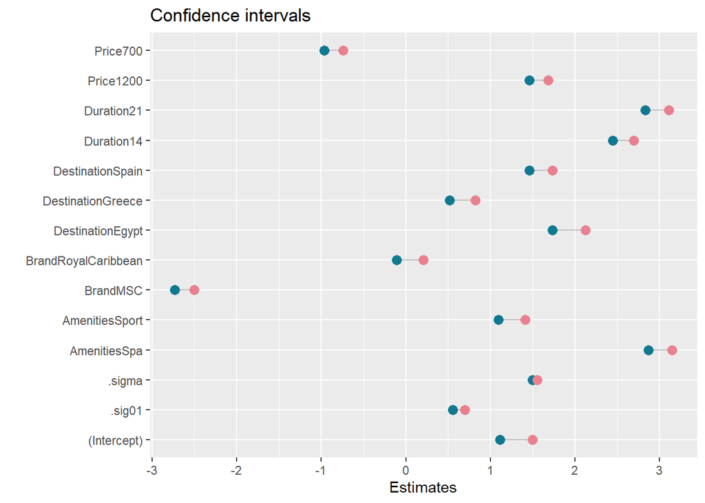

```r
rnames <- rownames(CI)
newCI <- cbind(CI, rnames)
newCI <- as.data.frame(newCI)
newCI$`2.5 %`<- as.numeric(newCI$`2.5 %`)
newCI$`97.5 %`<- as.numeric(newCI$`97.5 %`)
newCI$rnames <- as.factor(newCI$rnames)
colnames(newCI) <- c("lower", "upper", "group")

library(ggplot2)

ggplot(newCI) +
  geom_segment( aes(x=group, xend=group, y=lower, yend=upper), color="grey") +
  geom_point( aes(x=group, y=lower), color="#107991", size=3 ) + #rgb(0.2,0.7,0.1,0.5)
  geom_point( aes(x=group, y=upper), color="#e9808f", size=3 ) + #rgb(0.7,0.2,0.1,0.5)
  coord_flip()+
  ggtitle("Confidence intervals") +
  xlab("") +
  ylab("Estimates")
```

From a visual analysis, we can see that intervals are small, meaning that our estimates are quite precise. Moreover, it is easier to notice that all the estimates are positive, except for the ones of the Brand MSC and the Price of 700 euros. As we are assuming the point of view of Costa, we can appreciate the fact that our brand seems to be stronger in shaping the consumers’ preferences than the MSC one.

## Fixed and random effects

Now we can distinguish between the fixed effects and the random effects of the model.

```r
fixef(mlmRI)
```

```
##         (Intercept)            BrandMSC BrandRoyalCaribbean    DestinationEgypt
##          1.31299466         -2.61419953          0.05220184          1.93307080
##   DestinationGreece    DestinationSpain            Price700           Price1200
##          0.66281041          1.60499838         -0.85032517          1.57240851
##          Duration14          Duration21        AmenitiesSpa      AmenitiesSport
##          2.56912441          2.95859998          3.00193146          1.25489687
```

```r
ranef(mlmRI)
```

```
## $resp.id
##     (Intercept)
## 1   -0.22017208
## 2    0.24092128
## 3    0.12564794
## 4    0.12564794
## 5    0.04879905
## 6   -0.71968988
## 7   -0.60441654
## 8   -0.56599209
## 9   -0.75811432
## 10   0.66359018
## 11  -0.06647429
## 12  -0.18174763
## 13  -0.60441654
```

[output cut: 289 more lines]

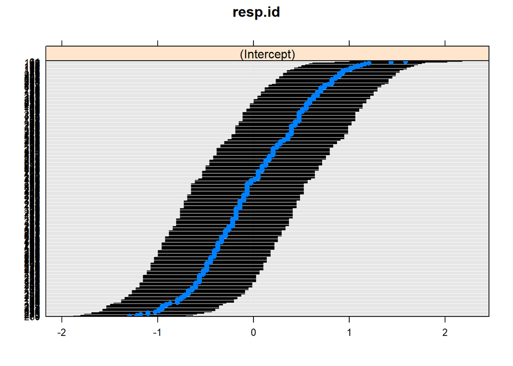

```r
dotplot(ranef(mlmRI))
```

The fixed effect of the intercept is the average of the distribution of the intercept parameters. Instead the random effects are the values that are summed to the intercept fixed effect to obtain the estimates of the intercept for each respondent. These estimates can be seen in the plot with their confidence intervals. Since they vary from values lower than -1 to values grater than 1, they have a non-negligible variance, which corresponds to the between-group variation. The first six estimates of the intercepts for every respondent are shown below, together with the ones of the other fixed parameters.

```r
head(coef(mlmRI)$resp.id)
```

|  | (Intercept) | BrandMSC | BrandRoyalCaribbean | DestinationEgypt | DestinationGreece | DestinationSpain | Price700 | Price1200 | Duration14 | Duration21 | AmenitiesSpa | AmenitiesSport |
| --- | --- | --- | --- | --- | --- | --- | --- | --- | --- | --- | --- | --- |
| 1 | 1.0928226 | -2.6142 | 0.05220184 | 1.933071 | 0.6628104 | 1.604998 | -0.8503252 | 1.572409 | 2.569124 | 2.9586 | 3.001931 | 1.254897 |
| 2 | 1.5539159 | -2.6142 | 0.05220184 | 1.933071 | 0.6628104 | 1.604998 | -0.8503252 | 1.572409 | 2.569124 | 2.9586 | 3.001931 | 1.254897 |
| 3 | 1.4386426 | -2.6142 | 0.05220184 | 1.933071 | 0.6628104 | 1.604998 | -0.8503252 | 1.572409 | 2.569124 | 2.9586 | 3.001931 | 1.254897 |
| 4 | 1.4386426 | -2.6142 | 0.05220184 | 1.933071 | 0.6628104 | 1.604998 | -0.8503252 | 1.572409 | 2.569124 | 2.9586 | 3.001931 | 1.254897 |
| 5 | 1.3617937 | -2.6142 | 0.05220184 | 1.933071 | 0.6628104 | 1.604998 | -0.8503252 | 1.572409 | 2.569124 | 2.9586 | 3.001931 | 1.254897 |
| 6 | 0.5933048 | -2.6142 | 0.05220184 | 1.933071 | 0.6628104 | 1.604998 | -0.8503252 | 1.572409 | 2.569124 | 2.9586 | 3.001931 | 1.254897 |

We extract the intercepts and plot their distribution using a density and a box plot.

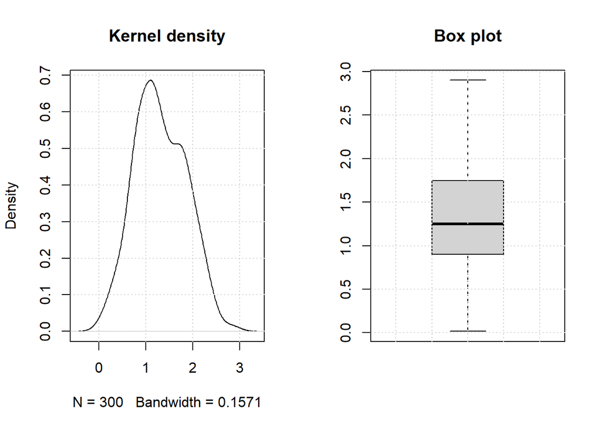

```r
interc <- coef(mlmRI)$resp.id[,1]
par(mfrow=c(1,2))
plot(density(interc), main="Kernel density") # kernel density
grid()
boxplot(interc, main="Box plot") # box plot
grid()
```

```r
mean(interc)
```

```
## [1] 1.312995
```

```r
median(interc)
```

```
## [1] 1.24652
```

From the plots, we can see that the highest frequency is in correspondence of 1.2 - 1.3, which is congruent with the estimate of the average intercept. Also the median is similar to the mean, as we can notice from the boxplot. The boxplot also highlights that the difference between the highest intercept and the median is greater (in absolute terms) than the one between the lowest value and the median. The density plot shows that there is a second bump, with a lower frequency than the first one. This could justify the fact that the mean is greater than the median, because it is pull to the right.

## Intraclass correlation coefficient and ad-hoc R-squared of the random intercept model

In order to assess the relevance of the grouping structure, we compute the intraclass correlation coefficient.

```r
par(mfrow=c(1,1))
vc <- as.data.frame(VarCorr(mlmRI))$vcov
icc <- function(x) {
  vc <- as.data.frame(VarCorr(x))$vcov
  vc[1]/sum(vc)
}
icc(mlmRI)
```

```
## [1] 0.1423468
```

The across-groups variability, which represents the heterogeneity between groups, explains 14% of the overall variability of the model. This is a non-negligible share, so using the grouping structure improves the estimates of the parameters.

Now we analyze the share of variance explained by the random intercept model, computing the ad hoc R-squared for models with grouping structure.

```r
NullModel <- lmer(rating ~ 1 + (1 | resp.id), data=cruise) #null model: we include just the intercept and the random effects for the intercept
R2level <- function(model){
  NM <- update(model, paste("~ 1 + (1 |", names(model@flist), ")"))
  vcNM <- as.data.frame(VarCorr(NM))$vcov
  vc <- as.data.frame(VarCorr(model))$vcov
  1 - sum(vc)/sum(vcNM)
}
R2level(mlmRI)
```

```
## [1] 0.6120085
```

The goodness-of-fit of our model is quite satisfying because it explains about 61% of the variance of the ratings above that accounted for in the null model.

## Intercept estimates according to different age groups

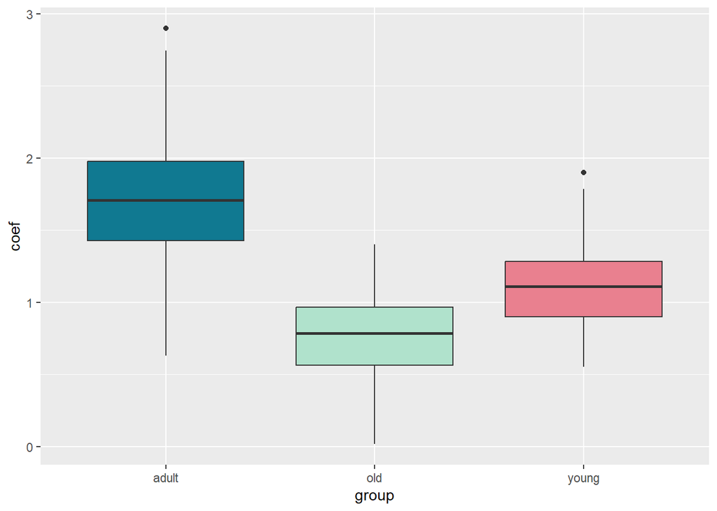

```r
interc_df <- data.frame(coef = interc, group = cruise$age[seq(1, length(cruise$age), 20)])
ggplot(interc_df, aes(x=group, y=coef, fill=group)) +
    geom_boxplot(fill = c("#107991", "#b0e2cc", "#e9808f"))
```

The boxplots highlight that the average values of the intercepts vary across groups of respondents with different age. In particular, controlling for the other predictors, adults assign the highest ratings to the cruise experience, followed by young respondents and, at last, the older ones. This may imply that the cruise company should focus on adults as their main target customers.

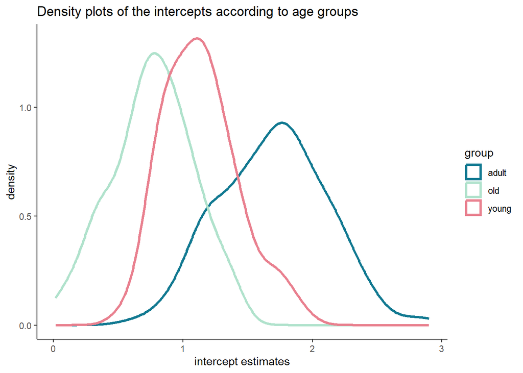

```r
library(ggplot2)
group <- cruise$age[seq(1, length(cruise$age), 20)]
interc_age <- as.data.frame(cbind(interc, group))
interc_age$group <- as.factor(interc_age$group)
levels(interc_age$group) <- c("adult", "old", "young")

# Basic density plot in ggplot2
ggplot(interc_age, aes(x = interc, colour = group)) +
  geom_density(lwd = 1.2) +
  theme_classic() +
  ggtitle("Density plots of the intercepts according to age groups") +
  xlab("intercept estimates")+
  scale_color_manual(values = c("#107991", "#b0e2cc", "#e9808f"))
```

As we have already seen in the boxplots above, the mean of the density distributions of the intercepts are different. Furthermore, there are differences between the variances of the groups. In particular, adults present the greatest heterogeneity, whereas young and old people seem to have quite similar preferences, controlling for the other predictors.

# Random slope model

Now we fit a model which estimates a random effect parameter for every attribute per each respondent.

```r
mlmRS <- lmer(rating ~ Brand + Destination + Price + Duration + Amenities + (Brand + Destination + Price + Duration + Amenities | resp.id),
              data=cruise)
```

```
## boundary (singular) fit: see help('isSingular')
```

```r
summary(mlmRS)
```

```
## Linear mixed model fit by REML ['lmerMod']
## Formula: rating ~ Brand + Destination + Price + Duration + Amenities +
##     (Brand + Destination + Price + Duration + Amenities | resp.id)
##    Data: cruise
##
## REML criterion at convergence: 16862.6
##
## Scaled residuals:
##     Min      1Q  Median      3Q     Max
## -3.3285 -0.5330 -0.0078  0.5489  3.4968
##
## Random effects:
##  Groups   Name                Variance Std.Dev. Corr
##  resp.id  (Intercept)         2.4254   1.5574
##           BrandMSC            0.3396   0.5827    0.43
##           BrandRoyalCaribbean 0.0917   0.3028    0.18  0.41
##           DestinationEgypt    0.2918   0.5402   -0.32 -0.77 -0.58
##           DestinationGreece   0.3463   0.5884   -0.26 -0.41 -0.58  0.79
##           DestinationSpain    0.3614   0.6012   -0.31 -0.47 -0.43  0.87  0.73
##           Price700            0.2543   0.5043   -0.75 -0.42  0.15  0.34  0.00
##           Price1200           0.3254   0.5705    0.64  0.32 -0.08 -0.05  0.04
##           Duration14          0.1361   0.3690   -0.51 -0.35 -0.33  0.33  0.10
##           Duration21          0.3371   0.5806   -0.32 -0.26 -0.28  0.22  0.05
##           AmenitiesSpa        3.0238   1.7389   -0.85 -0.22  0.17 -0.07 -0.05
##           AmenitiesSport      5.2593   2.2933   -0.76 -0.77 -0.22  0.56  0.23
##  Residual                     0.5221   0.7226
##
##
##
##
##
##
##
##   0.26
##   0.05 -0.55
##   0.17  0.59 -0.34
##   0.14  0.31 -0.16  0.85
##  -0.11  0.64 -0.86  0.29  0.12
##   0.44  0.70 -0.37  0.64  0.55  0.49
##
```

[output cut: 29 more lines]

```
## AmenitsSprt -0.736 -0.570 -0.094  0.309  0.218  0.361  0.458 -0.306  0.353
##             Drtn21 AmentsSp
## BrandMSC
## BrndRylCrbb
## DstntnEgypt
## DestintnGrc
## DestintnSpn
## Price700
## Price1200
## Duration14
## Duration21
## AmenitiesSp  0.066
## AmenitsSprt  0.312  0.512
## optimizer (nloptwrap) convergence code: 0 (OK)
## boundary (singular) fit: see help('isSingular')
```

Analyzing the correlations of the fixed effects, as we have seen also in the random intercept model above, the values with the greatest magnitude are the ones between the levels belonging to the same attributes. In particular, the highest positive correlation can be detected between destinations Spain and Greece. Hence, if a respondent tends to evaluate positively a cruise profile which is headed to Spain, he would give also a high positive score to a profile destined to Greece.

## Coefficients and Random effects

In contrast with the previous random intercept model, now we can see that the estimates of either the intercept and the other predictors vary across respondents:

```r
head(ranef(mlmRS)$resp.id)
```

|  | (Intercept) | BrandMSC | BrandRoyalCaribbean | DestinationEgypt | DestinationGreece | DestinationSpain | Price700 | Price1200 | Duration14 | Duration21 | AmenitiesSpa | AmenitiesSport |
| --- | --- | --- | --- | --- | --- | --- | --- | --- | --- | --- | --- | --- |
| 1 | -0.68001707 | 0.4488901 | 0.257138795 | -0.3643646 | 0.2506718 | -0.3336149 | -0.03296309 | -0.32271674 | -0.101209762 | -0.09741453 | 1.63194439 | -0.9170888 |
| 2 | -1.07992226 | -0.8118791 | -0.139041147 | 0.6264900 | 0.7271518 | 0.3652844 | 0.20506879 | -0.08109283 | 0.051050255 | -0.12175339 | 0.65395998 | 2.3900257 |
| 3 | -0.43889451 | -0.5767656 | -0.038220962 | 0.3196659 | -0.2401465 | 0.3165641 | 0.35226626 | -0.05637149 | -0.002678261 | -0.19414743 | 0.02813834 | 1.8739973 |
| 4 | -0.24633617 | -0.6046230 | 0.009415308 | 0.2140430 | -0.2349385 | 0.1439474 | 0.19174752 | -0.29660110 | -0.064006015 | -0.15166151 | 0.40642787 | 1.4778910 |
| 5 | 2.12429638 | 0.2801934 | -0.091218518 | 0.2653244 | 0.7231045 | 0.3645989 | -0.71798047 | 0.77005303 | -0.356104560 | -0.27477069 | -2.70152572 | -2.7315449 |
| 6 | -0.04555345 | 0.1515351 | 0.077775091 | -0.1797792 | -0.2229335 | -0.1851631 | 0.08602895 | -0.43331202 | -0.257942879 | -0.61867001 | 0.85141960 | -1.5660433 |

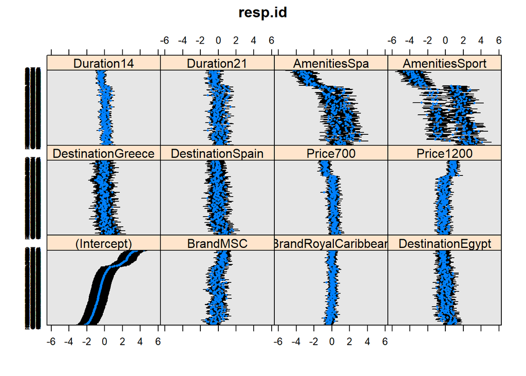

```r
dotplot(ranef(mlmRS), cex=0.4)
```

From the dotplots of the random effects of the parameters, it emerges that the ones with the highest variability are the intercepts and the amenities (which have also the highest variances in the summary of the model). Instead, duration and destination does not seem to have a great heterogeneity between respondents. Hence, we now fit some models where we use these variables just with their fixed effects and we compare the performances with the full random slope model.

Taking a closer look at the summary of the distribution of the random effects:

```r
summary(ranef(mlmRS)$resp.id)
```

```
##   (Intercept)         BrandMSC        BrandRoyalCaribbean DestinationEgypt
##  Min.   :-2.2438   Min.   :-1.40691   Min.   :-0.81800    Min.   :-0.96392
##  1st Qu.:-1.0119   1st Qu.:-0.39460   1st Qu.:-0.15542    1st Qu.:-0.33010
##  Median :-0.4368   Median : 0.04872   Median : 0.01096    Median :-0.06978
##  Mean   : 0.0000   Mean   : 0.00000   Mean   : 0.00000    Mean   : 0.00000
##  3rd Qu.: 0.4534   3rd Qu.: 0.41694   3rd Qu.: 0.17421    3rd Qu.: 0.31696
##  Max.   : 4.4449   Max.   : 1.08414   Max.   : 0.65706    Max.   : 1.21474
##  DestinationGreece  DestinationSpain      Price700         Price1200
##  Min.   :-1.04272   Min.   :-1.22862   Min.   :-1.2152   Min.   :-0.92446
##  1st Qu.:-0.25071   1st Qu.:-0.34351   1st Qu.:-0.1858   1st Qu.:-0.42974
##  Median :-0.02515   Median :-0.05723   Median : 0.1062   Median :-0.05957
##  Mean   : 0.00000   Mean   : 0.00000   Mean   : 0.0000   Mean   : 0.00000
##  3rd Qu.: 0.24840   3rd Qu.: 0.31949   3rd Qu.: 0.3084   3rd Qu.: 0.32614
##  Max.   : 1.56987   Max.   : 1.69204   Max.   : 0.9402   Max.   : 1.48091
##    Duration14          Duration21        AmenitiesSpa     AmenitiesSport
##  Min.   :-0.725446   Min.   :-1.17447   Min.   :-4.3025   Min.   :-4.6779
##  1st Qu.:-0.231347   1st Qu.:-0.36720   1st Qu.:-0.6796   1st Qu.:-1.5079
##  Median :-0.005113   Median :-0.07189   Median : 0.2892   Median : 0.5734
##  Mean   : 0.000000   Mean   : 0.00000   Mean   : 0.0000   Mean   : 0.0000
##  3rd Qu.: 0.235587   3rd Qu.: 0.30293   3rd Qu.: 1.3314   3rd Qu.: 1.9644
##  Max.   : 0.852920   Max.   : 1.38578   Max.   : 3.1468   Max.   : 4.1265
```

And of the ones for the coefficients (which are just the estimates coming from the model summary plus the random effects):

```r
summary(coef(mlmRS)$resp.id)
```

```
##   (Intercept)         BrandMSC      BrandRoyalCaribbean DestinationEgypt
##  Min.   :-0.9308   Min.   :-4.021   Min.   :-0.76580    Min.   :0.9691
##  1st Qu.: 0.3011   1st Qu.:-3.009   1st Qu.:-0.10322    1st Qu.:1.6030
##  Median : 0.8762   Median :-2.565   Median : 0.06316    Median :1.8633
##  Mean   : 1.3130   Mean   :-2.614   Mean   : 0.05220    Mean   :1.9331
##  3rd Qu.: 1.7664   3rd Qu.:-2.197   3rd Qu.: 0.22641    3rd Qu.:2.2500
##  Max.   : 5.7579   Max.   :-1.530   Max.   : 0.70927    Max.   :3.1478
##  DestinationGreece DestinationSpain    Price700          Price1200
##  Min.   :-0.3799   Min.   :0.3764   Min.   :-2.06550   Min.   :0.648
##  1st Qu.: 0.4121   1st Qu.:1.2615   1st Qu.:-1.03615   1st Qu.:1.143
##  Median : 0.6377   Median :1.5478   Median :-0.74408   Median :1.513
##  Mean   : 0.6628   Mean   :1.6050   Mean   :-0.85033   Mean   :1.572
##  3rd Qu.: 0.9112   3rd Qu.:1.9245   3rd Qu.:-0.54189   3rd Qu.:1.899
##  Max.   : 2.2327   Max.   :3.2970   Max.   : 0.08987   Max.   :3.053
##    Duration14      Duration21     AmenitiesSpa    AmenitiesSport
##  Min.   :1.844   Min.   :1.784   Min.   :-1.301   Min.   :-3.423
##  1st Qu.:2.338   1st Qu.:2.591   1st Qu.: 2.322   1st Qu.:-0.253
##  Median :2.564   Median :2.887   Median : 3.291   Median : 1.828
##  Mean   :2.569   Mean   :2.959   Mean   : 3.002   Mean   : 1.255
##  3rd Qu.:2.805   3rd Qu.:3.262   3rd Qu.: 4.333   3rd Qu.: 3.219
##  Max.   :3.422   Max.   :4.344   Max.   : 6.149   Max.   : 5.381
```

Histograms of coefficients frequencies

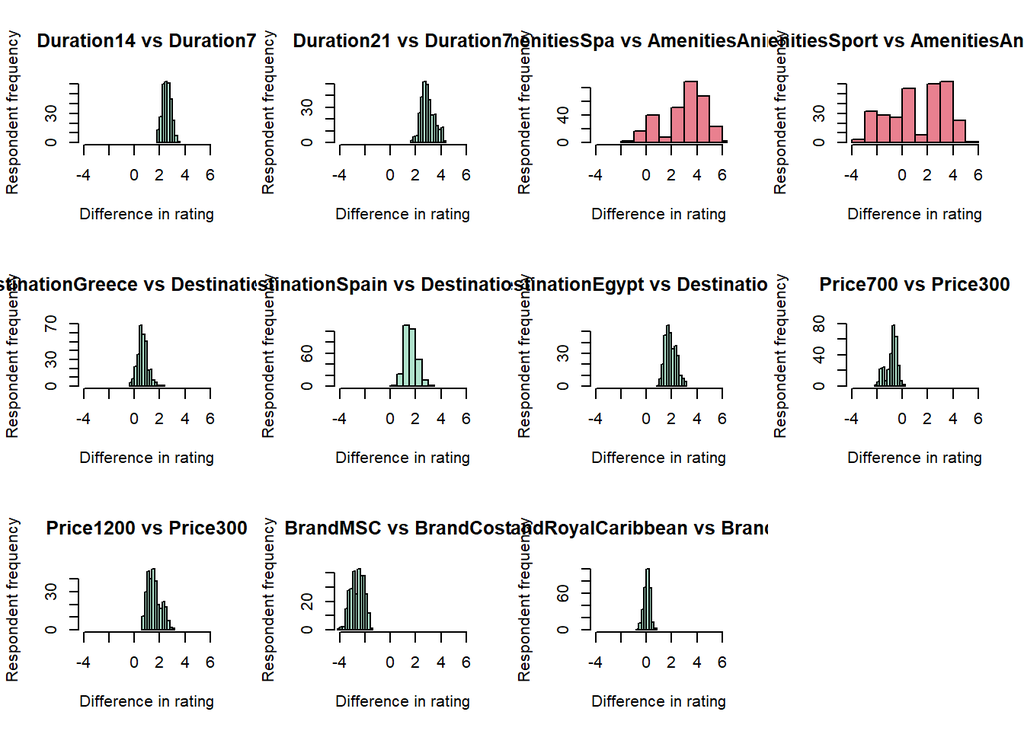

```r
par(mfrow = c(3,4))
hist(coef(mlmRS)$resp.id$Duration14, xlim = c(-4,6), main = "Duration14 vs Duration7", ylab = "Respondent frequency", xlab = "Difference in rating", col = "#b0e2cc")
hist(coef(mlmRS)$resp.id$Duration21, xlim = c(-4,6), main = "Duration21 vs Duration7", ylab = "Respondent frequency", xlab = "Difference in rating", col = "#b0e2cc")
hist(coef(mlmRS)$resp.id$AmenitiesSpa, xlim = c(-4,6), main = "AmenitiesSpa vs AmenitiesAnimation", ylab = "Respondent frequency", xlab = "Difference in rating", col = "#e9808f")
hist(coef(mlmRS)$resp.id$AmenitiesSport, xlim = c(-4,6), main = "AmenitiesSport vs AmenitiesAnimation", ylab = "Respondent frequency", xlab = "Difference in rating", col = "#e9808f")
hist(coef(mlmRS)$resp.id$DestinationGreece, xlim = c(-4,6), main = "DestinationGreece vs DestinationSicily", ylab = "Respondent frequency", xlab = "Difference in rating", col = "#b0e2cc")
hist(coef(mlmRS)$resp.id$DestinationSpain, xlim = c(-4,6), main = "DestinationSpain vs DestinationSicily", ylab = "Respondent frequency", xlab = "Difference in rating", col = "#b0e2cc")
hist(coef(mlmRS)$resp.id$DestinationEgypt, xlim = c(-4,6), main = "DestinationEgypt vs DestinationSicily", ylab = "Respondent frequency", xlab = "Difference in rating", col = "#b0e2cc")
hist(coef(mlmRS)$resp.id$Price700, xlim = c(-4,6), main = "Price700 vs Price300", ylab = "Respondent frequency", xlab = "Difference in rating", col = "#b0e2cc")
hist(coef(mlmRS)$resp.id$Price1200, xlim = c(-4,6), main = "Price1200 vs Price300", ylab = "Respondent frequency", xlab = "Difference in rating", col = "#b0e2cc")
hist(coef(mlmRS)$resp.id$BrandMSC, xlim = c(-4,6), main = "BrandMSC vs BrandCosta", ylab = "Respondent frequency", xlab = "Difference in rating", col = "#b0e2cc")
hist(coef(mlmRS)$resp.id$BrandRoyalCaribbean, xlim = c(-4,6), main = "BrandRoyalCaribbean vs BrandCosta", ylab = "Respondent frequency", xlab = "Difference in rating", col = "#b0e2cc")
#hist(coef(mlmRS)$resp.id$`(Intercept)`, main = "Intercept", ylab = "Respondent frequency", xlab = "Difference in rating")
par(mfrow = c(1,1))
```

The above graphs are quite useful in order to visually compare ranges and magnitude of the coefficients. We can easily see how much the variable Amenities with all its levels is affected by the grouping structure, so consumers are highly differentiated according to those attributes. Indeed their random effect estimates of the variance are considerably high: 3.0238328 for Spa and 5.2592643 for Sport. For sport it is even more interesting that even coefficients vary both below and above zero, so there is some segmentation according to this factor.

```r
ranges <- apply(coef(mlmRS)$resp.id, 2,FUN = range)
ranges_values <- ranges[2,] - ranges[1,]
```

## Comparison of performance with respect to simpler models

Now we try to estimate some simpler models and see how they compare in terms of performance.

```r
# Random slope model with duration and destination having just fixed effects
mlmRS_dur_des <- lmer(rating ~ Brand + Destination + Price + Duration + Amenities + (Brand + Price + Amenities | resp.id), data=cruise, control=lmerControl(optCtrl=list(maxfun=1e5)))
```

```
## boundary (singular) fit: see help('isSingular')
```

```r
summary(mlmRS_dur_des)
```

```
## Linear mixed model fit by REML ['lmerMod']
## Formula: rating ~ Brand + Destination + Price + Duration + Amenities +
##     (Brand + Price + Amenities | resp.id)
##    Data: cruise
## Control: lmerControl(optCtrl = list(maxfun = 1e+05))
##
## REML criterion at convergence: 17390.2
##
## Scaled residuals:
##     Min      1Q  Median      3Q     Max
## -3.5479 -0.5767 -0.0028  0.5842  3.6336
##
## Random effects:
##  Groups   Name                Variance Std.Dev. Corr
##  resp.id  (Intercept)         1.8419   1.3572
##           BrandMSC            0.2115   0.4599    0.41
##           BrandRoyalCaribbean 0.1431   0.3783    0.20  0.08
##           Price700            0.2833   0.5323   -0.74 -0.62 -0.08
##           Price1200           0.2632   0.5130    0.69  0.28  0.16 -0.47
##           AmenitiesSpa        2.8956   1.7017   -0.93 -0.29 -0.16  0.65 -0.90
##           AmenitiesSport      5.4697   2.3387   -0.63 -0.75 -0.33  0.76 -0.32
##  Residual                     0.6691   0.8180
##
##
##
##
##
##
##
##   0.47
##
## Number of obs: 6000, groups:  resp.id, 300
##
## Fixed effects:
##                     Estimate Std. Error t value
## (Intercept)          1.31299    0.09336  14.064
## BrandMSC            -2.61420    0.03978 -65.714
## BrandRoyalCaribbean  0.05220    0.05004   1.043
## DestinationEgypt     1.93307    0.05046  38.307
## DestinationGreece    0.66281    0.04103  16.153
```

[output cut: 20 more lines]

```
## AmenitsSprt -0.620 -0.459 -0.145  0.002  0.100  0.085  0.476 -0.249 -0.009
##             Drtn21 AmentsSp
## BrandMSC
## BrndRylCrbb
## DstntnEgypt
## DestintnGrc
## DestintnSpn
## Price700
## Price1200
## Duration14
## Duration21
## AmenitiesSp -0.027
## AmenitsSprt -0.088  0.503
## optimizer (nloptwrap) convergence code: 0 (OK)
## boundary (singular) fit: see help('isSingular')
```

The control parameter has been added in order to avoid an error message linked to the limited number of iterations with respect to the number of parameters in the model.

```r
anova(mlmRS_dur_des, mlmRS, refit=FALSE)
```

|  | npar | AIC | BIC | logLik | deviance | Chisq | Df | Pr(>Chisq) |
| --- | --- | --- | --- | --- | --- | --- | --- | --- |
| mlmRS_dur_des | 41 | 17472.17 | 17746.85 | -8695.084 | 17390.17 | NA | NA | NA |
| mlmRS | 91 | 17044.62 | 17654.27 | -8431.309 | 16862.62 | 527.5492 | 50 | 6.34283e-81 |

```r
# Random slope model with duration having just fixed effects
mlmRS_dur <- lmer(rating ~ Brand + Destination + Price + Duration + Amenities + (Brand + Price + Amenities + Destination | resp.id), data=cruise, control=lmerControl(optCtrl=list(maxfun=1e5)))
summary(mlmRS_dur)
```

```
## Linear mixed model fit by REML ['lmerMod']
## Formula: rating ~ Brand + Destination + Price + Duration + Amenities +
##     (Brand + Price + Amenities + Destination | resp.id)
##    Data: cruise
## Control: lmerControl(optCtrl = list(maxfun = 1e+05))
##
## REML criterion at convergence: 17102.3
##
## Scaled residuals:
##     Min      1Q  Median      3Q     Max
## -3.5463 -0.5506 -0.0055  0.5692  3.5132
##
## Random effects:
##  Groups   Name                Variance Std.Dev. Corr
##  resp.id  (Intercept)         2.0910   1.4460
##           BrandMSC            0.3289   0.5735    0.43
##           BrandRoyalCaribbean 0.2673   0.5170    0.28  0.47
##           Price700            0.2591   0.5090   -0.73 -0.44 -0.14
##           Price1200           0.2707   0.5203    0.64  0.30  0.15 -0.56
##           AmenitiesSpa        2.9633   1.7214   -0.87 -0.23 -0.06  0.68 -0.87
##           AmenitiesSport      5.6457   2.3761   -0.70 -0.78 -0.57  0.64 -0.39
##           DestinationEgypt    0.3140   0.5603   -0.32 -0.75 -0.68  0.35  0.06
##           DestinationGreece   0.3624   0.6020   -0.30 -0.46 -0.62  0.05  0.00
##           DestinationSpain    0.3895   0.6241   -0.30 -0.52 -0.54  0.25  0.03
##  Residual                     0.5747   0.7581
##
##
##
##
##
##
##
##   0.49
##  -0.07  0.69
##  -0.01  0.40  0.81
##  -0.09  0.55  0.87  0.77
##
## Number of obs: 6000, groups:  resp.id, 300
##
## Fixed effects:
```

[output cut: 26 more lines]

```
## AmenitsSprt -0.677 -0.564 -0.325  0.380  0.329  0.433  0.403 -0.301 -0.008
##             Drtn21 AmentsSp
## BrandMSC
## BrndRylCrbb
## DstntnEgypt
## DestintnGrc
## DestintnSpn
## Price700
## Price1200
## Duration14
## Duration21
## AmenitiesSp -0.025
## AmenitsSprt -0.081  0.509
## optimizer (nloptwrap) convergence code: 0 (OK)
## Model failed to converge with max|grad| = 0.00838705 (tol = 0.002, component 1)
```

```r
anova(mlmRS_dur, mlmRS, refit=FALSE)
```

|  | npar | AIC | BIC | logLik | deviance | Chisq | Df | Pr(>Chisq) |
| --- | --- | --- | --- | --- | --- | --- | --- | --- |
| mlmRS_dur | 68 | 17238.31 | 17693.88 | -8551.157 | 17102.31 | NA | NA | NA |
| mlmRS | 91 | 17044.62 | 17654.27 | -8431.309 | 16862.62 | 239.696 | 23 | 5.49805e-38 |

```r
# Random slope model with destination having just fixed effects
mlmRS_des <- lmer(rating ~ Brand + Destination + Price + Duration + Amenities + (Brand + Price + Amenities + Duration | resp.id), data=cruise, control=lmerControl(optCtrl=list(maxfun=1e5)))
summary(mlmRS_des)
```

```
## Linear mixed model fit by REML ['lmerMod']
## Formula: rating ~ Brand + Destination + Price + Duration + Amenities +
##     (Brand + Price + Amenities + Duration | resp.id)
##    Data: cruise
## Control: lmerControl(optCtrl = list(maxfun = 1e+05))
##
## REML criterion at convergence: 17144.9
##
## Scaled residuals:
##     Min      1Q  Median      3Q     Max
## -3.2180 -0.5609 -0.0069  0.5697  3.3544
##
## Random effects:
##  Groups   Name                Variance Std.Dev. Corr
##  resp.id  (Intercept)         2.19768  1.4825
##           BrandMSC            0.23491  0.4847    0.42
##           BrandRoyalCaribbean 0.07037  0.2653   -0.03 -0.13
##           Price700            0.29662  0.5446   -0.74 -0.63  0.41
##           Price1200           0.31113  0.5578    0.67  0.27  0.11 -0.46
##           AmenitiesSpa        2.95786  1.7198   -0.89 -0.27  0.04  0.58 -0.89
##           AmenitiesSport      5.10935  2.2604   -0.74 -0.81  0.24  0.80 -0.30
##           Duration14          0.12458  0.3530   -0.54 -0.31 -0.14  0.61 -0.26
##           Duration21          0.35298  0.5941   -0.34 -0.34 -0.06  0.41 -0.04
##  Residual                     0.61534  0.7844
##
##
##
##
##
##
##
##   0.48
##   0.30  0.65
##   0.09  0.63  0.88
##
## Number of obs: 6000, groups:  resp.id, 300
##
## Fixed effects:
##                     Estimate Std. Error t value
## (Intercept)          1.31299    0.09846  13.335
```

[output cut: 24 more lines]

```
## AmenitsSprt -0.712 -0.523  0.067  0.002  0.100  0.084  0.516 -0.245  0.326
##             Drtn21 AmentsSp
## BrandMSC
## BrndRylCrbb
## DstntnEgypt
## DestintnGrc
## DestintnSpn
## Price700
## Price1200
## Duration14
## Duration21
## AmenitiesSp  0.039
## AmenitsSprt  0.344  0.508
## optimizer (nloptwrap) convergence code: 0 (OK)
## Model failed to converge with max|grad| = 0.0068014 (tol = 0.002, component 1)
```

```r
anova(mlmRS_des, mlmRS, refit=FALSE)
```

|  | npar | AIC | BIC | logLik | deviance | Chisq | Df | Pr(>Chisq) |
| --- | --- | --- | --- | --- | --- | --- | --- | --- |
| mlmRS_des | 58 | 17260.93 | 17649.50 | -8572.463 | 17144.93 | NA | NA | NA |
| mlmRS | 91 | 17044.62 | 17654.27 | -8431.309 | 16862.62 | 282.308 | 33 | 2.253032e-41 |

## Random effect coefficients according to age

Let’s now consider again the respondent-level variable age and see how random effects are distributed according to it.

We will examine such relationship for the coefficients for which we saw have proven to have an effect on the group-level structure, having variation on a respondent-level.

### Amenities

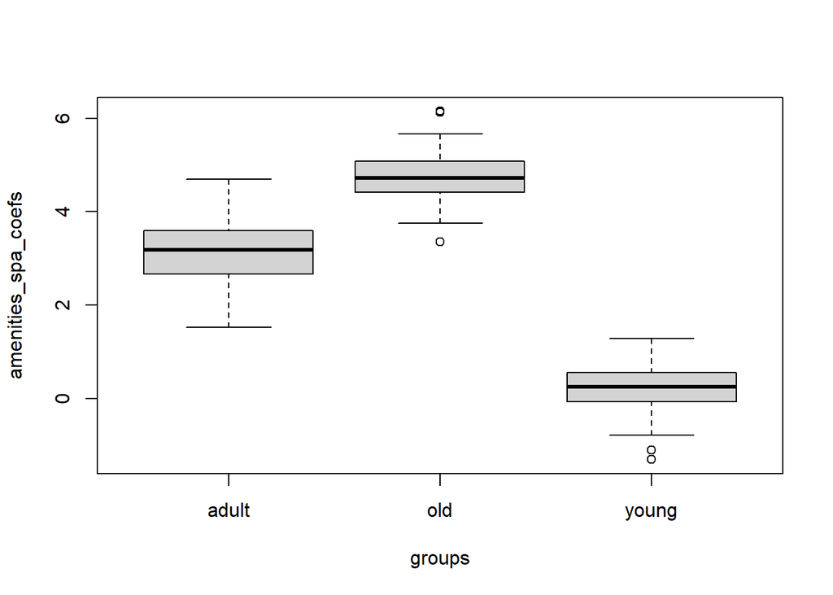

```r
amenities_spa_coefs <- coef(mlmRS)$resp.id[,11]
groups <- cruise$age[seq(1, length(cruise$age), 20)]
boxplot(amenities_spa_coefs ~ groups)
```

Only young consumers exhibit some coefficients lower than zero, which means they are more segmented. In fact, some of them prefer animation and others prefer spa.

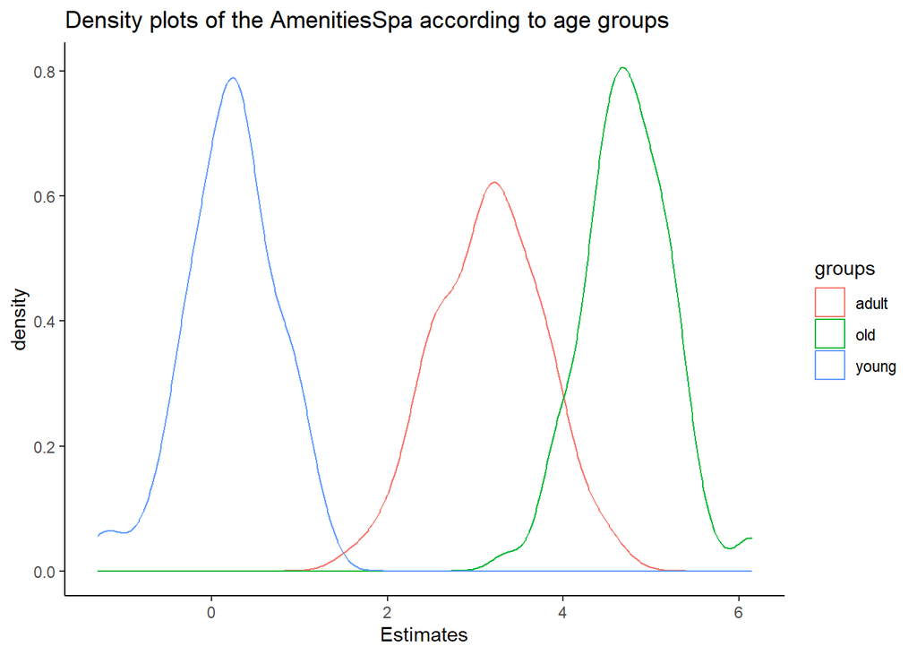

```r
spa_age <- as.data.frame(cbind(amenities_spa_coefs, groups))
spa_age$groups <- as.factor(spa_age$groups)
levels(spa_age$groups) <- c("adult", "old", "young")

ggplot(spa_age, aes(x = amenities_spa_coefs, colour = groups)) +
  geom_density() +
  theme_classic() +
  ggtitle("Density plots of the AmenitiesSpa according to age groups") +
  xlab("Estimates")
```

Again we can see a differentiation in groups’ variance, with the one of adult being higher. This is also further explained by the fact that the adult group is much more represented in the sample of respondents.

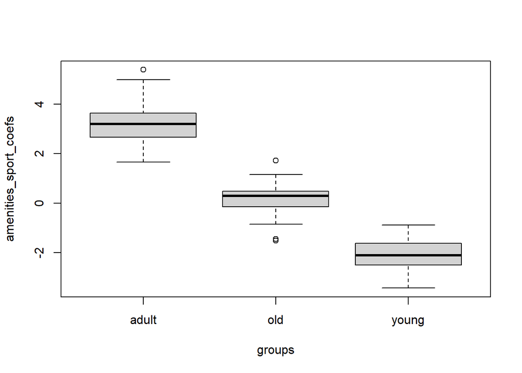

```r
amenities_sport_coefs <- coef(mlmRS)$resp.id[,12]
boxplot(amenities_sport_coefs ~ groups)
```

An interesting thing to notice is that for the group of young respondents, all the coefficients related to the sport level are below zero, which means that such kind of customers actually prefer animation than sport facilities on their ship.

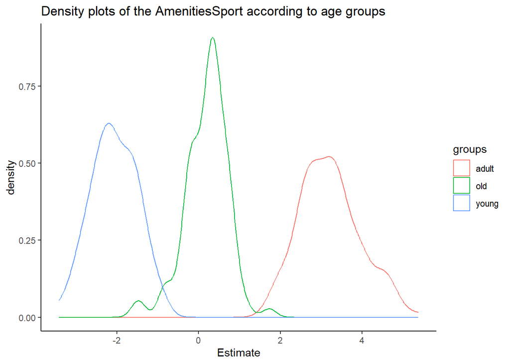

```r
sport_age <- as.data.frame(cbind(amenities_sport_coefs, groups))
sport_age$groups <- as.factor(sport_age$groups)
levels(sport_age$groups) <- c("adult", "old", "young")
ggplot(sport_age, aes(x = amenities_sport_coefs, colour = groups)) +
  geom_density() +
  theme_classic() +
  ggtitle("Density plots of the AmenitiesSport according to age groups") +
  xlab("Estimate")
```

Adults value amenities a lot and almost all adults have a coefficient for this variable larger than the coefficients for old and young consumers. For a firm to gain more customers therefore, would better consider adding a cruise line where sport amenities are included in order to gather more middle-aged customers.

### Destination

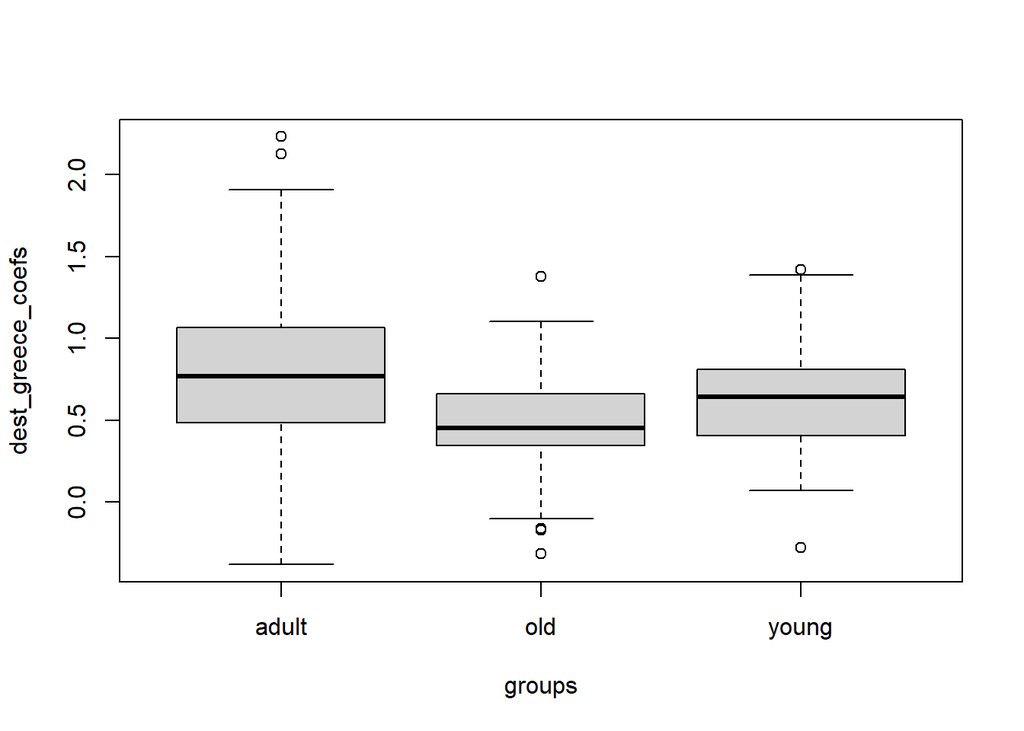

```r
dest_greece_coefs <- coef(mlmRS)$resp.id[,5]
boxplot(dest_greece_coefs ~ groups)
```

Not a significant difference.

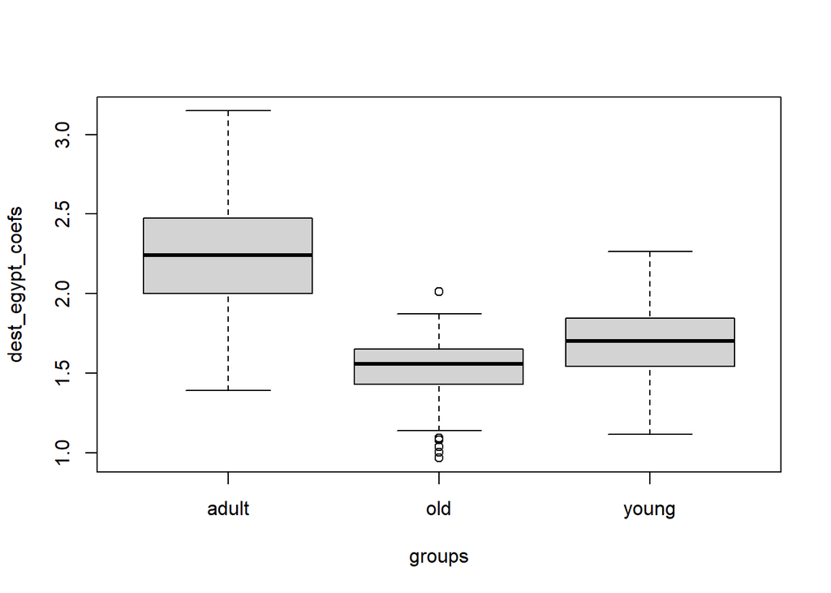

```r
dest_egypt_coefs <- coef(mlmRS)$resp.id[,4]
boxplot(dest_egypt_coefs ~ groups)
```

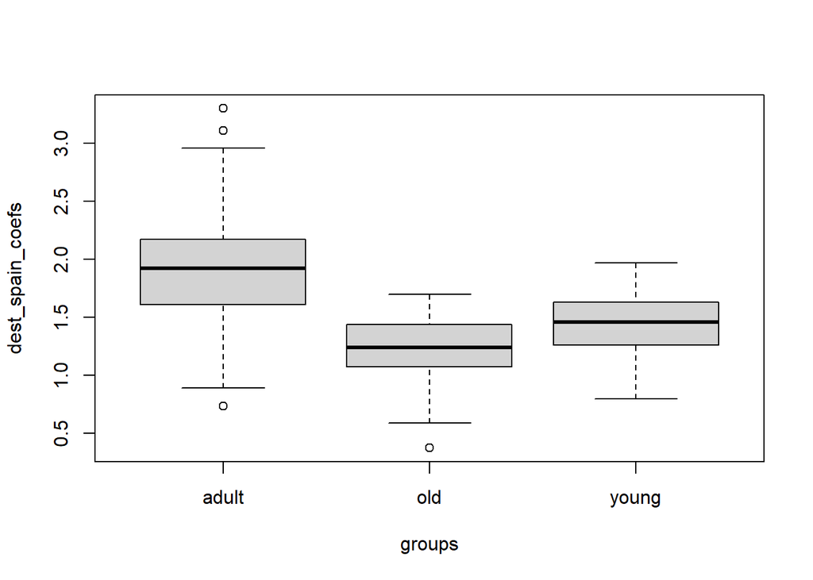

```r
dest_spain_coefs <- coef(mlmRS)$resp.id[,6]
boxplot(dest_spain_coefs ~ groups)
```

There are not many significant differences, apart from the higher variability in estimates for adults and the higher mean and median (more evident for the destinations of Egypt and Spain).

### Price

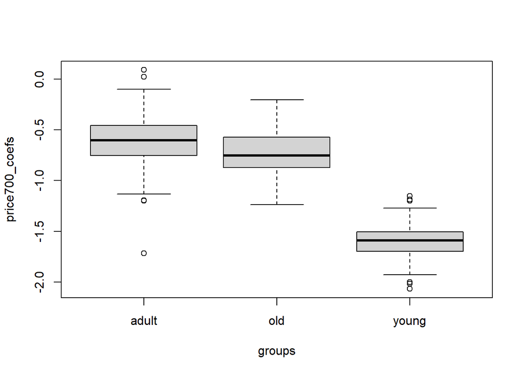

```r
price700_coefs <- coef(mlmRS)$resp.id[,7]

#summary(price700_df$coef[price700_df$group == "adult"])
#summary(price700_df$coef[price700_df$group == "old"])
#summary(price700_df$coef[price700_df$group == "young"])

boxplot(price700_coefs ~ groups)
```

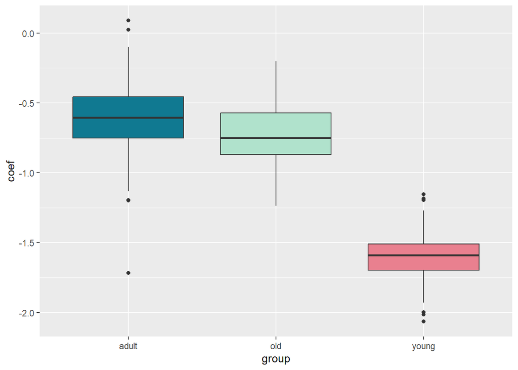

```r
#ggplot
price700_df <- data.frame(coef = price700_coefs, group = cruise$age[seq(1, length(cruise$age), 20)])
ggplot(price700_df, aes(x=group, y=coef, fill=group)) +
    geom_boxplot(fill = c("#107991", "#b0e2cc", "#e9808f"))
```

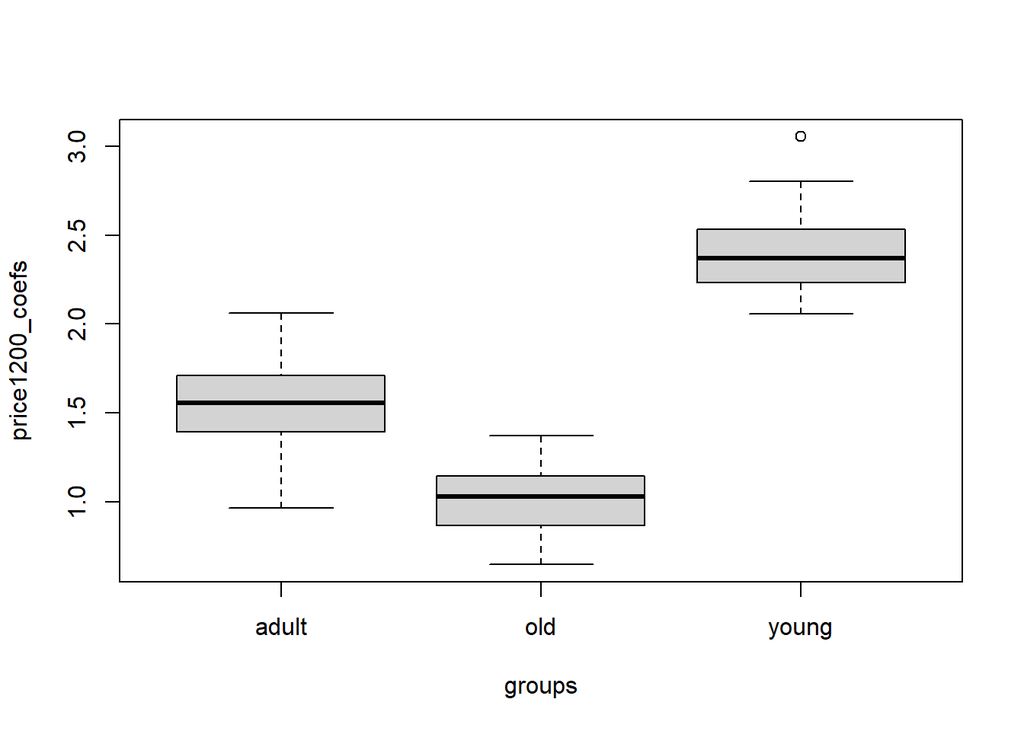

```r
price1200_coefs <- coef(mlmRS)$resp.id[,8]
boxplot(price1200_coefs ~ groups)
```

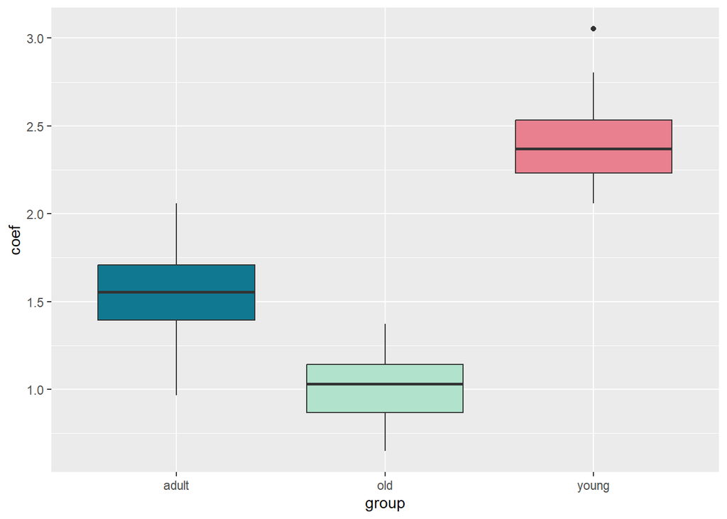

```r
#ggplot
price1200_df <- data.frame(coef = price1200_coefs, group = cruise$age[seq(1, length(cruise$age), 20)])
ggplot(price1200_df, aes(x=group, y=coef, fill=group)) +
    geom_boxplot(fill = c("#107991", "#b0e2cc", "#e9808f"))
```

In case of price of 700, almost all the respondent-level coefficients estimated are negative. On the contrary, they are all positive if we consider price of 1200 (w.r.t. the base 300). Further, we can notice that adults and seniors exhibit quite similar preferences, whereas youngsters’ distributions are much more polarized.

# Conclusions

The traditional conjoint analysis conducted on 300 respondents reveals that the grouping structure of data can explain a non negligible share of the variability of preferences. Looking at the results of the analysis, we may point out what follows: 1. Brand Royal Caribbean is not significant in shaping the consumer preferences, whereas Brand MSC is less preferred than Costa. Hence, if we assume the point of view of Costa, we can be quite confident about the strength of our brand, without the necessity to invest in its reinforcement, but just in its maintenance. 2. Duration has a strong effect in shaping the consumer preferences, because its estimates have a non negligible magnitude. In particular, longer voyages are preferred, hence a new cruise proposal for summer 2023 could last at least 14 days or, even better, 21. 3. The amenities on the cruise are very important too and they present a considerable heterogeneity among different age groups, as underlined by the analysis conducted with the random slope model. Youngsters prefer animation to sport. On the contrary, adults value sport amenities a lot and they are also the customers who assign the greatest rankings to the overall cruise experience (as emerged in the random intercept model). Hence, the cruise company could take into consideration the possibility of creating two different summer proposals: one destined to young customers, with more animations on board, and another one designed for middle-age and older customers, with a greater presence of sport and spa activities.  
4. As regards the price, it seems that a cruise of 300 euros is preferred to one priced 700 euros, but 1200 is preferred to 300 euros. In particular, the lowest estimates for the level Price700 are registered for young customers, who are also the age group with the highest estimates for Price1200. Hence, the cruise company, in shaping the two different offers described before, could propose a higher quality experience to youngsters, for example focusing on expensive animations and attractions, which are the levels of amenities that they prefer the most. Instead, for adults and old customers, the cruise company could take into consideration the possibility to offer two different experiences: one cheaper (with a price around 300 euros) and one more expensive (about 1200 euros), in order to satisfy the preferences of both the customers who evaluate more a price of 300 than 700 and the ones who prefer instead 1200. 5. Last but not least, the destination of the cruise does not seem to be one of the most important attribute in shaping the consumer preferences. Moreover, there is no considerable variability between different age groups. Hence, the cruise company could assign to the new proposals for summer 2023 the destination that is less costly for its own budget.